# R Tutorial

# Utilities

## Clear variables

### Clear single variable

```r
var <- 20
rm( var )
```

### Clear environment

```r
rm( list = ls() )
```

## Restart R

Session -> Restart R

## Current Working Directory

### Get Working Directory

```r
cat( getwd() )
```

```
/Users/filippo/Documents/University/courses/BI/R_tutorial
```

### Set Working Directory

```r
setwd( "/Users/filippo/Documents/University/courses/BI/R_tutorial" )
```

### Files and directories in Current Directory

```r
cat( "List of files: \n", list.files(), "\n\n" )
```

```
List of files:
 notebook.nb.html notebook.Rmd R_tutorial.Rproj
```

```r
cat( "List of directories: \n", list.dirs() )
```

```
List of directories:
 . ./.git ./.git/hooks ./.git/info ./.git/objects ./.git/objects/info ./.git/objects/pack ./.git/refs ./.git/refs/heads ./.git/refs/tags ./.Rproj.user ./.Rproj.user/63B8F073 ./.Rproj.user/63B8F073/bibliography-index ./.Rproj.user/63B8F073/ctx ./.Rproj.user/63B8F073/explorer-cache ./.Rproj.user/63B8F…
```

# Data types

## Numeric

```r
cat( "num: ", 3, "\nclass( 3 ): ", class( 3 ) )
```

```
num:  3
class( 3 ):  numeric
```

## Integer

```r
cat( "int: ", 3L, "\nclass( 3L ): ", class( 3L ) )
```

```
int:  3
class( 3L ):  integer
```

## Boolean

```r
cat( "bool: ", TRUE, "\nclass( TRUE ): ", class( TRUE ) )
```

```
bool:  TRUE
class( TRUE ):  logical
```

## Characters

```r
cat( "char: ", "Hello", "\nclass( \"Hello\" ): ", class( "Hello" ) )
```

```
char:  Hello
class( "Hello" ):  character
```

# Variables

## Simple assignment operation

```r
a <- 2
# a = 2
# assign( "a", 2 )
cat( "a: ", a, "\n" )
```

```
a:  2
```

## Operations on variables

```r
b <- a * 3
# b <- a / 2
# b <- a + a
# b <- a - 4
cat( "b: ", b )
```

```
b:  6
```

## Floating point variables

```r
f <- b * 3.14
# f <- 18.84
cat( "f: ", f )
```

```
f:  18.84
```

# Vectors

## Vector initialization via `c()` function

```r
v_int <- c( 1, 2, 3, 4 )
cat( "v_int: ", v_int )
```

```
v_int:  1 2 3 4
```

## Vector of floats via vector operations

```r
v_float <- v_int * 3.14
# v_float <- v_int / 2.
# v_float <- v_int - 1.0001
# v_float <- v_int * f
# v_float <- c( 3.14, 3.14 * 2, 3.14 * 3 )
cat( "v_float: ", v_float )
```

```
v_float:  3.14 6.28 9.42 12.56
```

## Reciprocal of a vector

```r
v_recipr <- 1 / v_int
cat( "v_recipr: ", v_recipr )
```

```
v_recipr:  1 0.5 0.3333333 0.25
```

## Concatenation of vectors and constants

```r
v_concat <- c( v_recipr, 0, v_int )
cat( "v_concat: ", v_concat )
```

```
v_concat:  1 0.5 0.3333333 0.25 0 1 2 3 4
```

## Sequence generation

```r
v_seq1 <- seq( 1, 9 )
cat( "v_seq1: ", v_seq1 )
```

```
v_seq1:  1 2 3 4 5 6 7 8 9
```

```r
v_seq2 <- seq( 1, 9, by = 2 )
cat( "v_seq2: ", v_seq2 )
```

```
v_seq2:  1 3 5 7 9
```

```r
v_seq3 <- seq( -10, 10, by = 2 )
cat( "v_seq3: ", v_seq3 )
```

```
v_seq3:  -10 -8 -6 -4 -2 0 2 4 6 8 10
```

```r
v_seq4 <- seq( -2, 2, by = .5 )
cat( "v_seq4: ", v_seq4 )
```

```
v_seq4:  -2 -1.5 -1 -0.5 0 0.5 1 1.5 2
```

## Repeat vectors

```r
v_rep1 <- rep( v_int, times = 2 )
cat( "v_rep1: ", v_rep1 )
```

```
v_rep1:  1 2 3 4 1 2 3 4
```

```r
v_rep2 <- rep( v_int, each = 4 )
cat( "v_rep2: ", v_rep2 )
```

```
v_rep2:  1 1 1 1 2 2 2 2 3 3 3 3 4 4 4 4
```

## Element-wise operations between vectors of same length

```r
v1 <- c( 1, 2, 3 )
cat( "v1: ", v1 )
```

```
v1:  1 2 3
```

```r
v2 <- c( 4, 5, 6 )
cat( "v2: ", v2 )
```

```
v2:  4 5 6
```

```r
v_sum <- v1 + v2
cat( "v_sum: ", v_sum )
```

```
v_sum:  5 7 9
```

```r
v_diff <- v2 - v1
cat( "v_diff: ", v_diff )
```

```
v_diff:  3 3 3
```

```r
v_mul <- v2 * v1
cat( "v_mul: ", v_mul )
```

```
v_mul:  4 10 18
```

```r
v_div <- v2 / v1
cat( "v_div: ", v_div )
```

```
v_div:  4 2.5 2
```

## Element-wise operations between vectors of different lengths

> Note that the two vectors should have lengths which are one the multiple of the other

```r
v3 <- c( 4, 5, 6, 7, 8, 9 )
cat( "v3: ", v3 )
```

```
v3:  4 5 6 7 8 9
```

It is like considering:

```r
# v1 = 1, 2, 3, 1, 2, 3
# v3 = 4, 5, 6, 7, 8, 9
```

The shortest vector is “repeated” as many times is needed in order to reach the longest length

```r
v_sum_diff_length <- v1 + v3
cat( "v_sum_diff_length: ", v_sum_diff_length )
```

```
v_sum_diff_length:  5 7 9 8 10 12
```

```r
v_diff_diff_length <- v3 - v1
cat( "v_diff_diff_length: ", v_diff_diff_length )
```

```
v_diff_diff_length:  3 3 3 6 6 6
```

```r
v_mul_diff_length <- v3 * v1
cat( "v_mul_diff_length: ", v_mul_diff_length )
```

```
v_mul_diff_length:  4 10 18 7 16 27
```

```r
v_div_diff_length <- v3 / v1
cat( "v_div_diff_length: ", v_div_diff_length )
```

```
v_div_diff_length:  4 2.5 2 7 4 3
```

## Length of a vector

```r
l_v1 <- length( v1 )
cat( "length( v1 ): ", l_v1 )
```

```
length( v1 ):  3
```

```r
l_v2 <- length( v2 )
cat( "length( v1 ): ", l_v2 )
```

```
length( v1 ):  3
```

```r
l_v3 <- length( v3 )
cat( "length( v1 ): ", l_v3 )
```

```
length( v1 ):  6
```

## Range operator

```r
r_v1 <- range( v1 )
cat( "range( v1 ): ", r_v1 )
```

```
range( v1 ):  1 3
```

```r
r_v2 <- range( v2 )
cat( "range( v2 ): ", r_v2 )
```

```
range( v2 ):  4 6
```

```r
r_v3 <- range( v3 )
cat( "range( v3 ): ", r_v3 )
```

```
range( v3 ):  4 9
```

## Min and Max operators

```r
min_v1 <- min( v1 )
cat( "min( v1 ): ", min_v1 )
```

```
min( v1 ):  1
```

```r
max_v1 <- max( v1 )
cat( "max( v1 ): ", max_v1 )
```

```
max( v1 ):  3
```

## Accessing vector elements

```r
first_element_v1 <- v1[ 1 ]
cat( "v1[ 1 ]: ", first_element_v1 )
```

```
v1[ 1 ]:  1
```

## Sort vectors

```r
v_unsrt <- c( 9, -23, 1, 3.14, 100, -598.121 )
cat( "v_unsrt: ", v_unsrt )
```

```
v_unsrt:  9 -23 1 3.14 100 -598.121
```

```r
v_srt_asc <- sort( v_unsrt )
cat( "v_srt_asc: ", v_srt_asc )
```

```
v_srt_asc:  -598.121 -23 1 3.14 9 100
```

```r
v_srt_desc <- sort( v_unsrt, decreasing = TRUE )
cat( "v_srt_desc: ", v_srt_desc )
```

```
v_srt_desc:  100 9 3.14 1 -23 -598.121
```

# Useful operators

## Modulo operator

```r
rest <- 10 %% 4
cat( "rest: ", rest )
```

```
rest:  2
```

## Square root

```r
square_root <- sqrt( 4 )
cat( "square_root: ", square_root )
```

```
square_root:  2
```

## Exponential operator

```r
exponential <- 10 ** 4
# e ^ 2 <- exp( 2 )
cat( "exponential: ", exponential )
```

```
exponential:  10000
```

# Other data structures

## Lists

Vectors contain elements which are all of the same type, lists can contain elements of different types.

```r
l <- list( c( 1, 2, 3 ), "Hello", FALSE, sin )
l
```

```
[[1]]
[1] 1 2 3

[[2]]
[1] "Hello"

[[3]]
[1] FALSE

[[4]]
function (x)  .Primitive("sin")
```

## Matrices

2D data structure.

```r
m1 <- matrix( c( 1, 2, 3, 4, 5, 6 ), nrow = 2 )
m1
```

```
     [,1] [,2] [,3]
[1,]    1    3    5
[2,]    2    4    6
```

```r
m2 <- matrix( c( 1, 2, 3, 4, 5, 6 ), nrow = 2, byrow = TRUE )
m2
```

```
     [,1] [,2] [,3]
[1,]    1    2    3
[2,]    4    5    6
```

```r
m3 <- matrix( c( 1, 2, 3, 4, 5, 6 ), nrow = 2, ncol = 9 )
m3
```

```
     [,1] [,2] [,3] [,4] [,5] [,6] [,7] [,8] [,9]
[1,]    1    3    5    1    3    5    1    3    5
[2,]    2    4    6    2    4    6    2    4    6
```

## Factors

Encodes a vector as a factor, i.e. a category or enumerated type (levels).

```r
province <- c( "Siena", "Firenze", "Pisa", "Firenze", "Siena", "Lucca", "Siena" )
fact <- factor( province )
print( fact )
```

```
[1] Siena   Firenze Pisa    Firenze Siena   Lucca   Siena
Levels: Firenze Lucca Pisa Siena
```

```r
cat( "nlevels( fact ): ", nlevels( fact ) )
```

```
nlevels( fact ):  4
```

```r
cat( "\nlevels( fact ): ", levels( fact ) )
```

```
levels( fact ):  Firenze Lucca Pisa Siena
```

## Dataframes

Tabularized data, different from matrices which can only stores elements of the same type.

```r
df <- data.frame( students_names = c( "Filippo", "Mary", "Pierre" ),
                  ages = c( 25, 22, 27 ),
                  passed = c( TRUE, TRUE, FALSE ) )
print( df )
```

| students_names | ages | passed |
| --- | --- | --- |
| Filippo | 25 | TRUE |
| Mary | 22 | TRUE |
| Pierre | 27 | FALSE |

```r
class( df )
```

```
[1] "data.frame"
```

```r
cat( "df$students_names: ", df$students_names )
```

```
df$students_names:  Filippo Mary Pierre
```

```r
cat( "\ndf$ages: ", df$ages )
```

```
df$ages:  25 22 27
```

```r
cat( "\ndf$passed: ", df$passed )
```

```
df$passed:  TRUE TRUE FALSE
```

```r
cat( "df[,1]: ", df[,1] )
```

```
df[,1]:  Filippo Mary Pierre
```

```r
cat( "\ndf[,2]: ", df[,2] )
```

```
df[,2]:  25 22 27
```

```r
cat( "\ndf[,3]: ", df[,3] )
```

```
df[,3]:  TRUE TRUE FALSE
```

```r
df[1,1]
```

```
[1] "Filippo"
```

```r
df[,2:3]
```

| ages | passed |
| --- | --- |
| 25 | TRUE |
| 22 | TRUE |
| 27 | FALSE |

```r
df[1:2,]
```

|  | students_names | ages | passed |
| --- | --- | --- | --- |
| 1 | Filippo | 25 | TRUE |
| 2 | Mary | 22 | TRUE |

```r
df[3,]
```

|  | students_names | ages | passed |
| --- | --- | --- | --- |
| 3 | Pierre | 27 | FALSE |

# Functions

## Function definition

```r
decimal_scaling <- function( vec )
{
  h <- ceiling( log10( max( abs( vec ) ) ) )
  return( vec / ( 10 ^ h ) )
}

min_max <- function( vec, new_min = 0, new_max = 1 )
{
  coefficient <- ( new_max - new_min ) / ( max( vec ) - min( vec ) )
  return( coefficient * ( vec - min( vec ) ) + new_min )
}

z_index <- function( vec )
{
  return( ( vec - mean( vec ) ) / sd( vec ) )
}
```

## Function call

```r
ds <- decimal_scaling( c( -976, 800, 390, 100 ) )
cat( "decimal_scaling: ", ds )
```

```
decimal_scaling:  -0.976 0.8 0.39 0.1
```

```r
mm_01 <- min_max( c( -976, 800, 390, 100 ) )
cat( "min_max in [0,1]: ", mm_01 )
```

```
min_max in [0,1]:  0 1 0.7691441 0.6058559
```

```r
mm_11 <- min_max( c( -976, 800, 390, 100 ), new_min = -1, new_max = 1 )
cat( "min_max in [-1,1]: ", mm_11 )
```

```
min_max in [-1,1]:  -1 1 0.5382883 0.2117117
```

```r
zi <- z_index( c( -976, 800, 390, 100 ) )
cat( "z-index: ", zi )
```

```
z-index:  -1.388612 0.9501026 0.4101968 0.02831214
```

# Datasets

## Read `.csv` files

```r
# read data from local .csv file
# df = read.csv( filename )
```

## Load built-in datasets

```r
# import the built-in datasets
library( datasets )

# show first rows
head( iris )
```

|  | Sepal.Length | Sepal.Width | Petal.Length | Petal.Width | Species |
| --- | --- | --- | --- | --- | --- |
| 1 | 5.1 | 3.5 | 1.4 | 0.2 | setosa |
| 2 | 4.9 | 3.0 | 1.4 | 0.2 | setosa |
| 3 | 4.7 | 3.2 | 1.3 | 0.2 | setosa |
| 4 | 4.6 | 3.1 | 1.5 | 0.2 | setosa |
| 5 | 5.0 | 3.6 | 1.4 | 0.2 | setosa |
| 6 | 5.4 | 3.9 | 1.7 | 0.4 | setosa |

## Number of rows and columns

```r
nrow( iris )
```

```
[1] 150
```

```r
ncol( iris )
```

```
[1] 5
```

## Missing values

```r
iris_missing <- iris
# check for missing values
print( all( complete.cases( iris_missing ) ) )
```

```
[1] TRUE
```

```r
# modify the dataset so that it contains a missing
iris_missing[ 5, 3 ] = NaN
head( iris_missing )
```

|  | Sepal.Length | Sepal.Width | Petal.Length | Petal.Width | Species |
| --- | --- | --- | --- | --- | --- |
| 1 | 5.1 | 3.5 | 1.4 | 0.2 | setosa |
| 2 | 4.9 | 3.0 | 1.4 | 0.2 | setosa |
| 3 | 4.7 | 3.2 | 1.3 | 0.2 | setosa |
| 4 | 4.6 | 3.1 | 1.5 | 0.2 | setosa |
| 5 | 5.0 | 3.6 | NaN | 0.2 | setosa |
| 6 | 5.4 | 3.9 | 1.7 | 0.4 | setosa |

```r
# check for missing values
print( all( complete.cases( iris_missing ) ) )
```

```
[1] FALSE
```

## Data elimination: elimination of the rows containing missing data

```r
iris_elimination <- iris_missing[ complete.cases( iris_missing), ]
print( nrow( iris_missing ) )
```

```
[1] 150
```

```r
print( nrow( iris_elimination ) )
```

```
[1] 149
```

## Data imputation

### Mean data imputation

```r
iris_mean_imputation <- iris_missing
for ( j in 1:ncol( iris_mean_imputation) )
{
  iris_mean_imputation[ is.na( iris_mean_imputation[ , j ] ), j ] <- mean( iris_mean_imputation[ , j ], na.rm = TRUE )
}
```

```
argument is not numeric or logical: returning NA
```

```r
head( iris_mean_imputation )
```

|  | Sepal.Length | Sepal.Width | Petal.Length | Petal.Width | Species |
| --- | --- | --- | --- | --- | --- |
| 1 | 5.1 | 3.5 | 1.400000 | 0.2 | setosa |
| 2 | 4.9 | 3.0 | 1.400000 | 0.2 | setosa |
| 3 | 4.7 | 3.2 | 1.300000 | 0.2 | setosa |
| 4 | 4.6 | 3.1 | 1.500000 | 0.2 | setosa |
| 5 | 5.0 | 3.6 | 3.773826 | 0.2 | setosa |
| 6 | 5.4 | 3.9 | 1.700000 | 0.4 | setosa |

# Plots

## Bar plots

```r
library( RColorBrewer )

cars <- mtcars
cars$carb
```

```
 [1] 4 4 1 1 2 1 4 2 2 4 4 3 3 3 4 4 4 1 2 1 1 2 2 4 2 1 2 2 4 6 8 2
```

```r
# table of counts
carb.count <- table( cars$carb )
carb.count
```

```
 1  2  3  4  6  8
 7 10  3 10  1  1
```

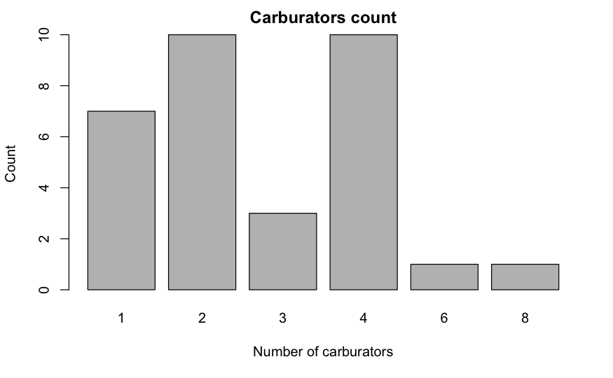

```r
# count barplot
barplot( carb.count,
         main = "Carburators count",
         xlab = "Number of carburators",
         ylab = "Count" )
```

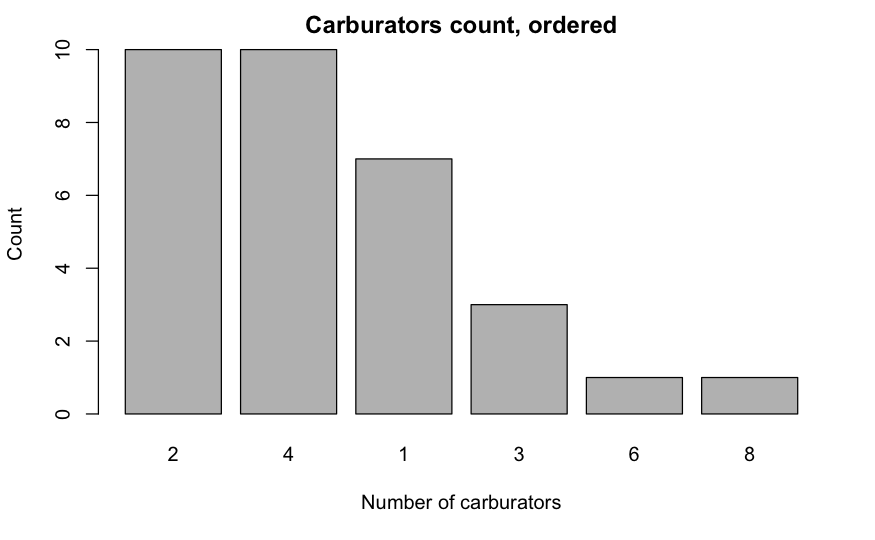

```r
# ordered count barplot
barplot( carb.count[ order( carb.count, decreasing = TRUE ) ],
         main = "Carburators count, ordered",
         xlab = "Number of carburators",
         ylab = "Count" )
```

```r
# table of frequencies
carb.freq <- prop.table( carb.count )
carb.freq
```

```
      1       2       3       4       6       8
0.21875 0.31250 0.09375 0.31250 0.03125 0.03125
```

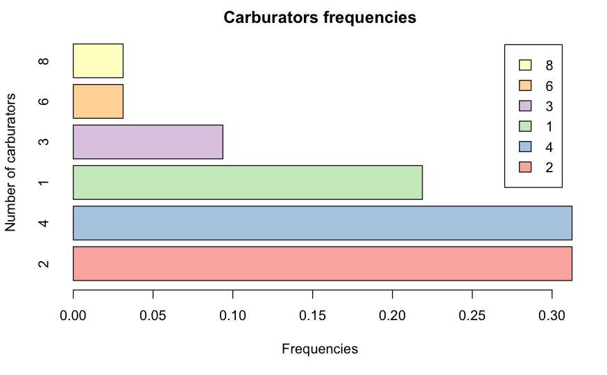

```r
# frequencies barplot
barplot( carb.freq[ order( carb.freq, decreasing = TRUE ) ],
         main = "Carburators frequencies",
         xlab = "Frequencies",
         ylab = "Number of carburators",
         col = brewer.pal( 6, "Pastel1" ),
         legend.text = TRUE,
         horiz = TRUE )
```

## Pie charts

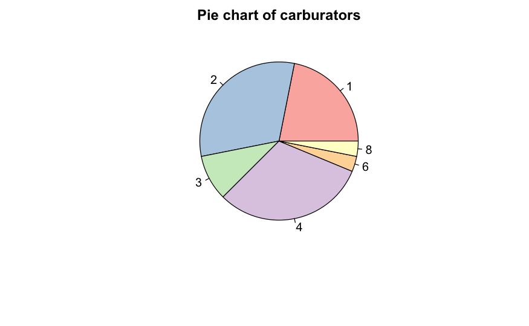

```r
pie( carb.freq,
     main = "Pie chart of carburators",
     col = brewer.pal( 6, "Pastel1" ))
```

## Histograms

```r
# create a vector of ages
age <- c( 26, 47, 58, 25, 60 )
# create a vector of names
name <- c( "Mary", "Paul", "John", "Sarah", "Martin" )

# column bind two vectors
age_name <- cbind( age, name )
age_name
```

```
     age  name
[1,] "26" "Mary"
[2,] "47" "Paul"
[3,] "58" "John"
[4,] "25" "Sarah"
[5,] "60" "Martin"
```

```r
# mean( age_name[ , 1 ] )   # returns NA since argument is not numeric
mean( as.numeric( age_name[ , 1 ] ) )
```

```
[1] 43.2
```

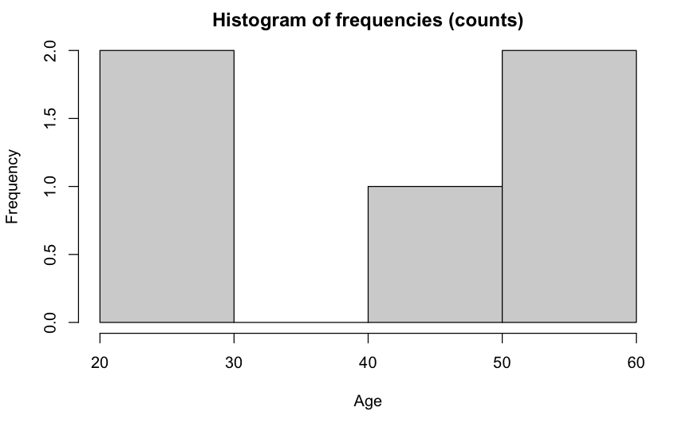

```r
# build the histogram of counts
hist( as.numeric( age_name[ , 1 ] ),
      main = "Histogram of frequencies (counts)",
      xlab = "Age")
```

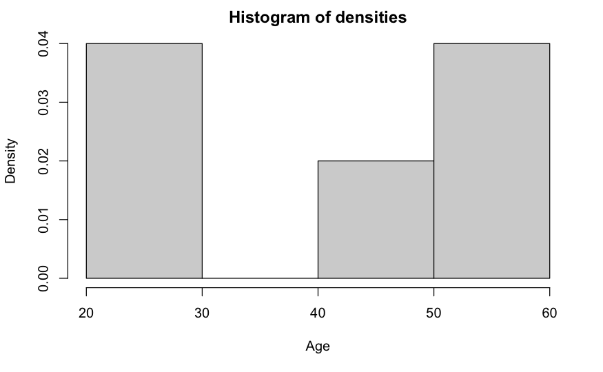

```r
# build the histogram of densities
hist( as.numeric( age_name[ , 1 ] ),
      main = "Histogram of densities",
      xlab = "Age",
      freq = FALSE )
```

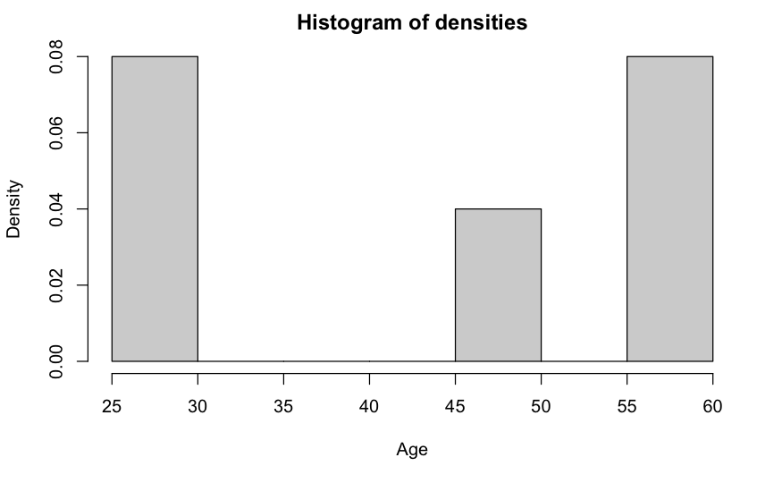

```r
# build the histogram of densities, with breaks = 5
hist( as.numeric( age_name[ , 1 ] ),
      main = "Histogram of densities",
      xlab = "Age",
      breaks = 5,
      freq = FALSE )
```

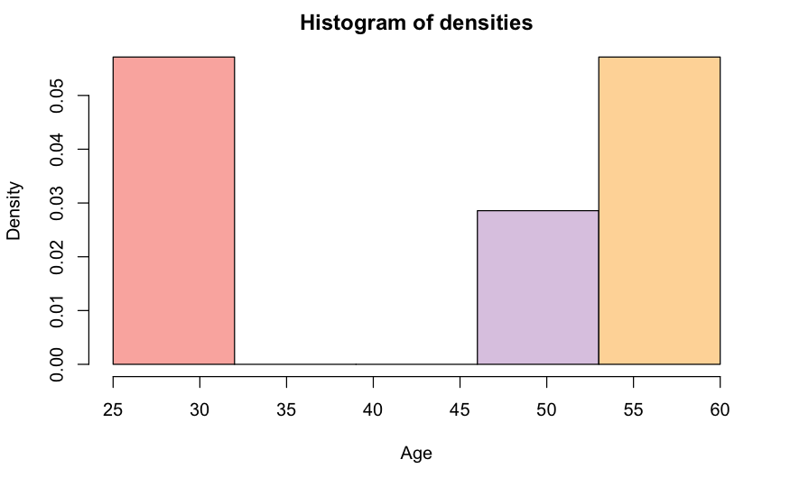

```r
# build the histogram of densities, partitioned per width
hist( as.numeric( age_name[ , 1 ] ),
      main = "Histogram of densities",
      xlab = "Age",
      breaks = c( 25, 32, 39, 46, 53, 60 ),
      freq = FALSE,
      col = brewer.pal(6, "Pastel1" ) )
```

## Boxplots

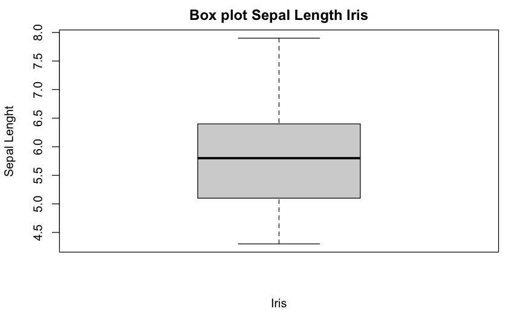

```r
boxplot( iris$Sepal.Length, main = "Box plot Sepal Length Iris", ylab = "Sepal Lenght", xlab = "Iris" )
```

# PCA

## Computation

```r
mtcars.pca <- princomp( mtcars, cor = FALSE )
```

## Summary

```r
summary( mtcars.pca )
```

```
Importance of components:
                            Comp.1     Comp.2       Comp.3       Comp.4
Standard deviation     134.3827868 37.5472829 3.0226510768 1.286072e+00
Proportion of Variance   0.9269989  0.0723684 0.0004689947 8.490294e-05
Cumulative Proportion    0.9269989  0.9993673 0.9998362482 9.999212e-01
                             Comp.5       Comp.6       Comp.7       Comp.8
Standard deviation     0.8922099047 6.530910e-01 3.037193e-01 2.814568e-01
Proportion of Variance 0.0000408626 2.189471e-05 4.735181e-06 4.066450e-06
Cumulative Proportion  0.9999620137 9.999839e-01 9.999886e-01 9.999927e-01
                             Comp.9      Comp.10      Comp.11
Standard deviation     2.467490e-01 2.073344e-01 1.952988e-01
Proportion of Variance 3.125380e-06 2.206656e-06 1.957902e-06
Cumulative Proportion  9.999958e-01 9.999980e-01 1.000000e+00
```

## Loadings

```r
loadings( mtcars.pca )
```

```
Loadings:
     Comp.1 Comp.2 Comp.3 Comp.4 Comp.5 Comp.6 Comp.7 Comp.8 Comp.9 Comp.10
mpg                 0.982                0.144
cyl                       -0.228 -0.239  0.794 -0.425 -0.189         0.132
disp -0.900  0.435
hp   -0.435 -0.899
drat                              0.133 -0.227        -0.939         0.184
wt                         0.128  0.244  0.127  0.187  0.156  0.391  0.830
qsec                       0.886  0.214  0.190 -0.255 -0.103        -0.204
vs                         0.177        -0.103               -0.684  0.303
am                        -0.136        -0.205 -0.201         0.572 -0.163
gear                      -0.130  0.276 -0.335 -0.802  0.217 -0.156  0.204
carb               -0.103 -0.269  0.855  0.284  0.165        -0.128 -0.240
     Comp.11
mpg
cyl  -0.145
disp
hp
drat
wt
qsec
vs   -0.626
am   -0.733
gear  0.191
carb

               Comp.1 Comp.2 Comp.3 Comp.4 Comp.5 Comp.6 Comp.7 Comp.8 Comp.9
SS loadings     1.000  1.000  1.000  1.000  1.000  1.000  1.000  1.000  1.000
Proportion Var  0.091  0.091  0.091  0.091  0.091  0.091  0.091  0.091  0.091
Cumulative Var  0.091  0.182  0.273  0.364  0.455  0.545  0.636  0.727  0.818
               Comp.10 Comp.11
SS loadings      1.000   1.000
Proportion Var   0.091   0.091
Cumulative Var   0.909   1.000
```

## Screen plot

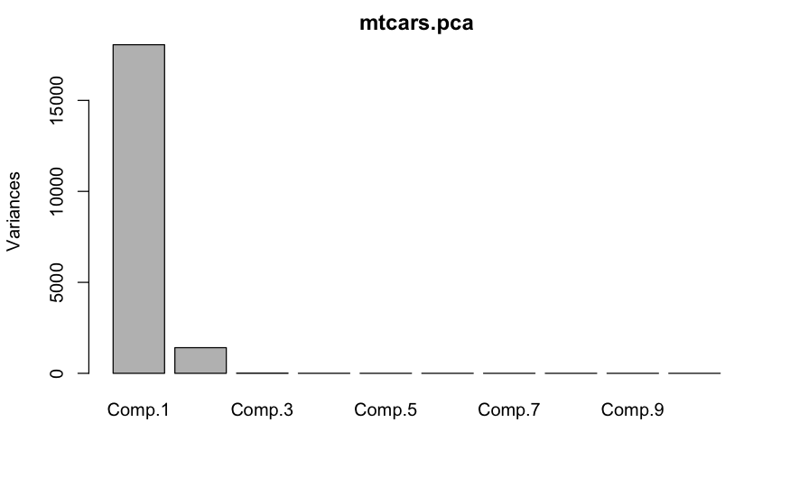

```r
plot( mtcars.pca )
```

## Autoplot

```r
library( ggfortify )
mtcars$carb
```

```
 [1] 4 4 1 1 2 1 4 2 2 4 4 3 3 3 4 4 4 1 2 1 1 2 2 4 2 1 2 2 4 6 8 2
```

```r
mtcars$carb <- as.factor( mtcars$carb )
mtcars$carb
```

```
 [1] 4 4 1 1 2 1 4 2 2 4 4 3 3 3 4 4 4 1 2 1 1 2 2 4 2 1 2 2 4 6 8 2
Levels: 1 2 3 4 6 8
```

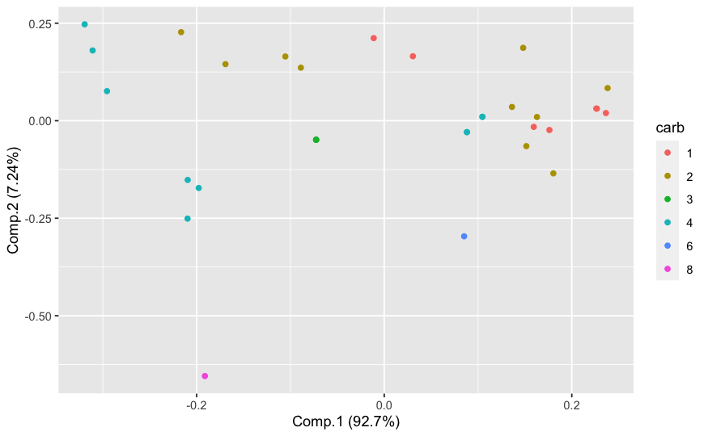

```r
autoplot( mtcars.pca, data = mtcars, colour = "carb" )
```

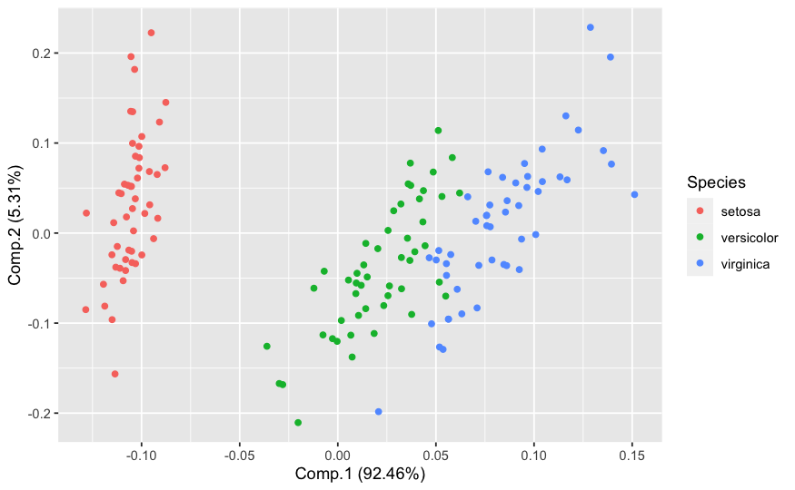

```r
autoplot( princomp( iris[ c( 1, 2, 3, 4 ) ] ), data = iris, label = FALSE, colour = "Species" )
```

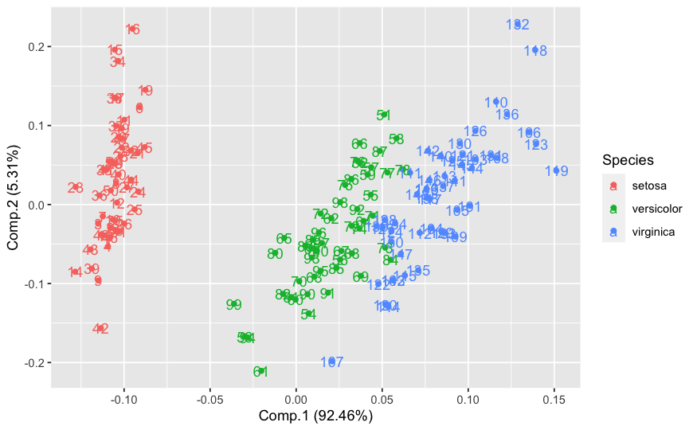

```r
autoplot( princomp( iris[ c( 1, 2, 3, 4 ) ] ), data = iris, label = TRUE, colour = "Species" )
```

# Statistical measures

## Mode

```r
get_mode <- function( values_vector )
{
  uniqv <- unique( values_vector )
  return ( uniqv[ which.max( tabulate( match( values_vector, uniqv ) ) ) ] )
}

get_mode( c(0,0,1,1,1,1,1,2,2,3,3,3,3,3,3,3,3 ) )
```

```
[1] 3
```

## Quantiles

```r
quantile( iris$Sepal.Length )
```

```
  0%  25%  50%  75% 100%
 4.3  5.1  5.8  6.4  7.9
```

```r
# The 0% quantile is the minimum
min( iris$Sepal.Length )
```

```
[1] 4.3
```

```r
# The 50% quantile is the median
median( iris$Sepal.Length )
```

```
[1] 5.8
```

```r
# The 100% quantile is the maximum
max( iris$Sepal.Length )
```

```
[1] 7.9
```

```r
# with probs one can change the steps of the quantile
quantile( iris$Sepal.Length, probs = seq( 0, 1, 0.1 ) )
```

```
  0%  10%  20%  30%  40%  50%  60%  70%  80%  90% 100%
4.30 4.80 5.00 5.27 5.60 5.80 6.10 6.30 6.52 6.90 7.90
```

## Gini Heterogeneity Index

```r
HetGini <- function( vec, relative = FALSE )
{
  vec.table <- table( vec )
  vec.freq <- prop.table( vec.table )
  squared_vector <- c()
  for( i in 1:nrow( vec.freq ) )
  {
    squared_vector <- cbind( squared_vector, vec.freq[ i ]^2 )
  }
  if( !relative )
  {
    return( 1 - sum( squared_vector ) )
  }
  else
  {
    if( nrow( vec.freq ) == 1 )
    {
      max_value = 1
    }
    else
    {
      max_value = ( nrow( vec.freq ) - 1 ) / ( nrow( vec.freq ) )
    }
    return( ( 1 - sum( squared_vector ) ) / max_value )
  }
}

vec_gini0 <- c( "Siena", "Siena", "Siena", "Siena", "Siena", "Siena", "Siena" )
HetGini( vec_gini0 )
```

```
[1] 0
```

```r
HetGini( vec_gini0, relative = TRUE )
```

```
[1] 0
```

```r
vec_gini1 <- c( "Siena", "Firenze", "Pisa", "Siena", "Siena", "Siena", "Siena", "Siena", "Siena" )
HetGini( vec_gini1 )
```

```
[1] 0.3703704
```

```r
HetGini( vec_gini1, relative = TRUE )
```

```
[1] 0.5555556
```

```r
vec_gini2 <- c( "Siena", "Firenze", "Pisa" )
HetGini( vec_gini2 )
```

```
[1] 0.6666667
```

```r
HetGini( vec_gini2, relative = TRUE )
```

```
[1] 1
```

## Skewness and kurtosis

```r
library( e1071 )
skewness( iris$Sepal.Length )
```

```
[1] 0.3086407
```

```r
kurtosis( iris$Sepal.Length )
```

```
[1] -0.6058125
```

## Correlation matrices and plots

```r
library( corrplot )
# correlation matrix take only numerical values

# cor() exploits pearson correlation coefficient by default
corr_matrix <- cor( iris[ , 1:4 ], method = "pearson" )
corr_matrix
```

```
             Sepal.Length Sepal.Width Petal.Length Petal.Width
Sepal.Length    1.0000000  -0.1175698    0.8717538   0.8179411
Sepal.Width    -0.1175698   1.0000000   -0.4284401  -0.3661259
Petal.Length    0.8717538  -0.4284401    1.0000000   0.9628654
Petal.Width     0.8179411  -0.3661259    0.9628654   1.0000000
```

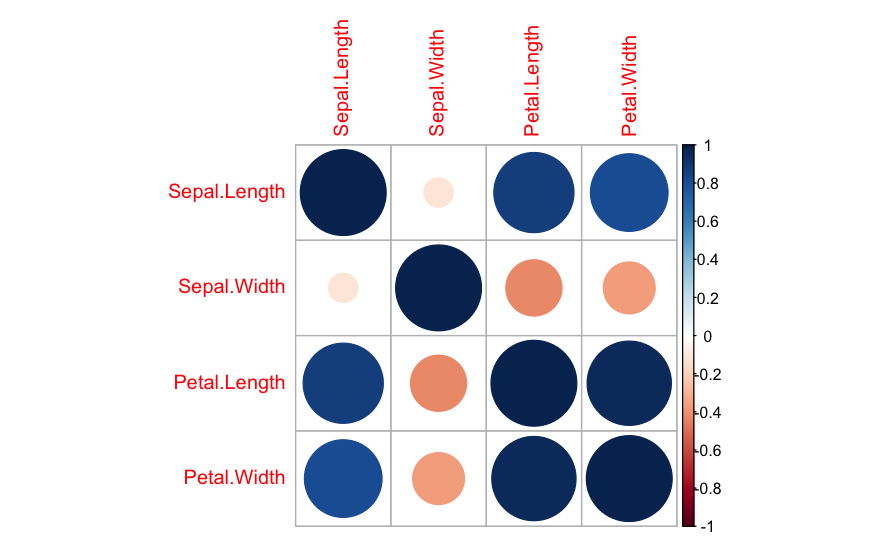

```r
corrplot( corr_matrix, method = "circle" )
```

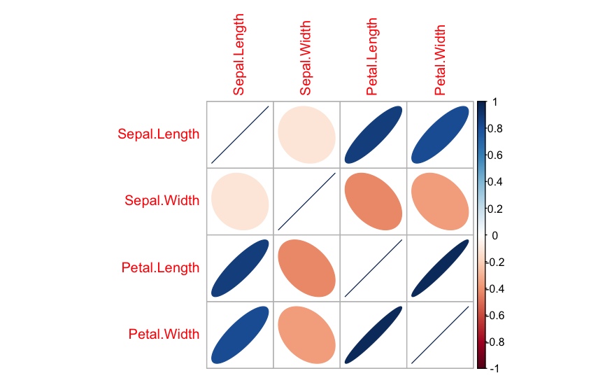

```r
corrplot( corr_matrix, method = "ellipse" )
```

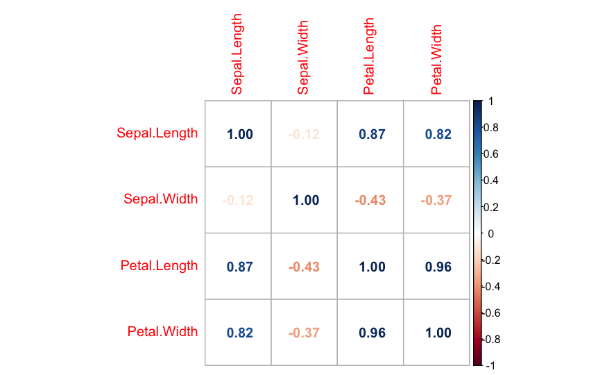

```r
corrplot( corr_matrix, method = "number" )
```

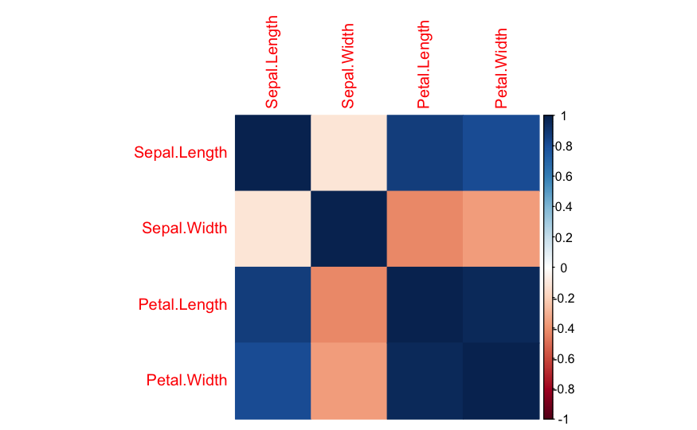

```r
corrplot( corr_matrix, method = "color" )
```

## Multi scatter plots

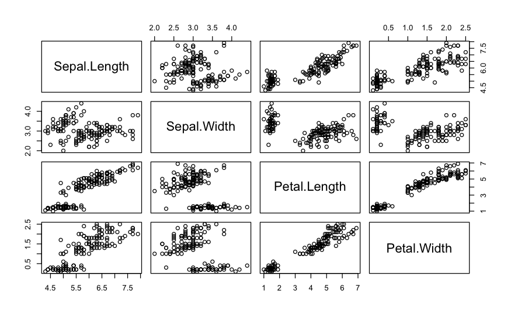

```r
plot( iris[ , 1:4 ] )
```

## Star plots

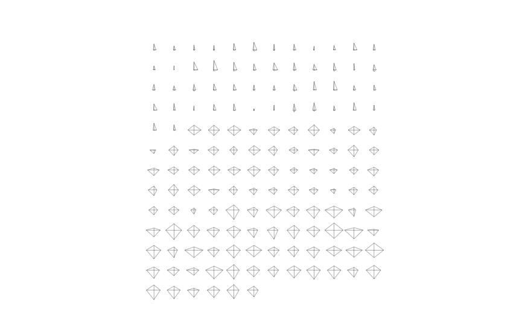

```r
stars( iris[ , 1:4 ] )
```

## Quantile-Quantile plots

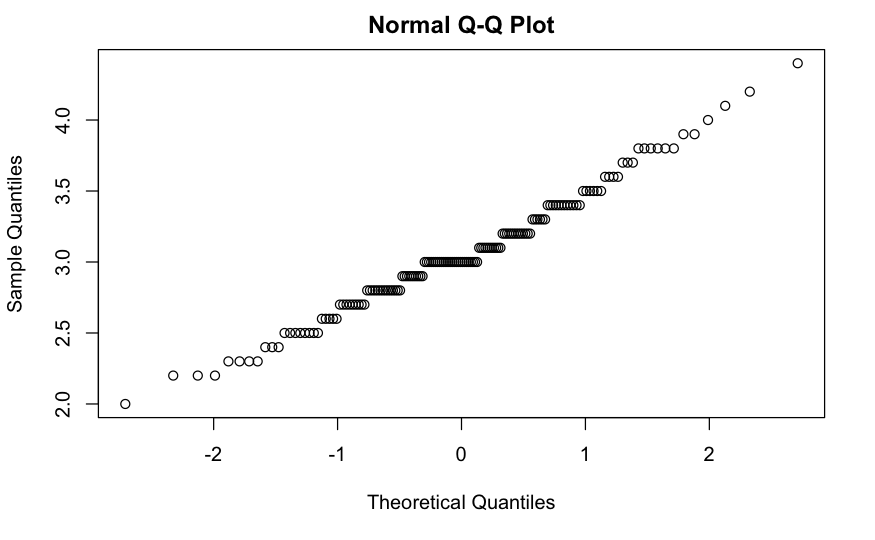

```r
qqnorm( iris$Sepal.Width )
```

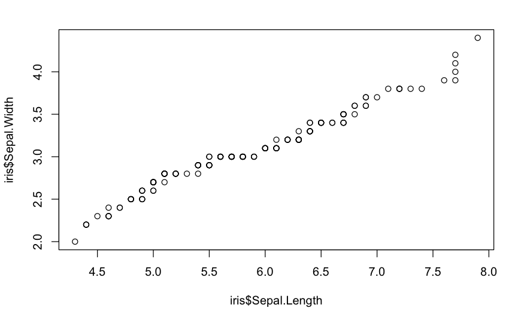

```r
qqplot( iris$Sepal.Length, iris$Sepal.Width )
```

## Box plots wrt class

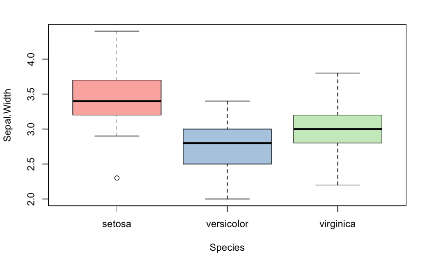

```r
boxplot( Sepal.Width ~ Species, data = iris, col = brewer.pal( 6, "Pastel1" ) )
```

## Contingency table

```r
contingency_table <- table( iris$Species, iris$Sepal.Length )
contingency_table
```

```
             4.3 4.4 4.5 4.6 4.7 4.8 4.9 5 5.1 5.2 5.3 5.4 5.5 5.6 5.7 5.8 5.9 6
  setosa       1   3   1   4   2   5   4 8   8   3   1   5   2   0   2   1   0 0
  versicolor   0   0   0   0   0   0   1 2   1   1   0   1   5   5   5   3   2 4
  virginica    0   0   0   0   0   0   1 0   0   0   0   0   0   1   1   3   1 2

             6.1 6.2 6.3 6.4 6.5 6.6 6.7 6.8 6.9 7 7.1 7.2 7.3 7.4 7.6 7.7 7.9
  setosa       0   0   0   0   0   0   0   0   0 0   0   0   0   0   0   0   0
  versicolor   4   2   3   2   1   2   3   1   1 1   0   0   0   0   0   0   0
  virginica    2   2   6   5   4   0   5   2   3 0   1   3   1   1   1   4   1
```

# Linear Regression

## Simple Linear Regression

```r
iris.reg <- lm( iris$Sepal.Length ~ iris$Sepal.Width )
summary( iris.reg )
```

```
Call:
lm(formula = iris$Sepal.Length ~ iris$Sepal.Width)

Residuals:
    Min      1Q  Median      3Q     Max
-1.5561 -0.6333 -0.1120  0.5579  2.2226

Coefficients:
                 Estimate Std. Error t value Pr(>|t|)
(Intercept)        6.5262     0.4789   13.63   <2e-16 ***
iris$Sepal.Width  -0.2234     0.1551   -1.44    0.152
---
Signif. codes:  0 ‘***’ 0.001 ‘**’ 0.01 ‘*’ 0.05 ‘.’ 0.1 ‘ ’ 1

Residual standard error: 0.8251 on 148 degrees of freedom
Multiple R-squared:  0.01382,   Adjusted R-squared:  0.007159
F-statistic: 2.074 on 1 and 148 DF,  p-value: 0.1519
```

## Scatter plot of the residual against the fitted values

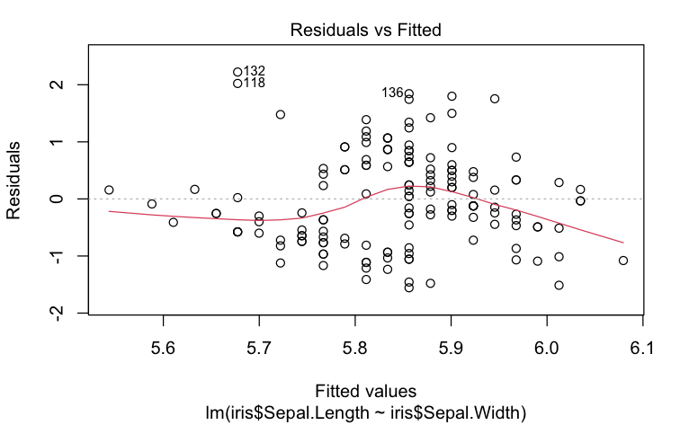

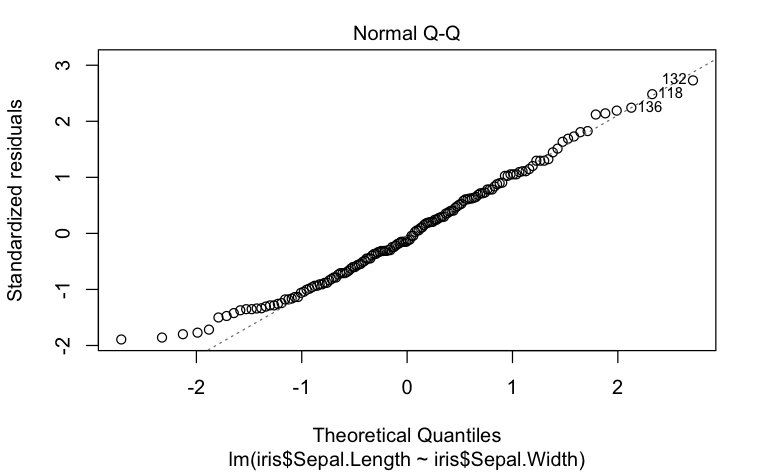

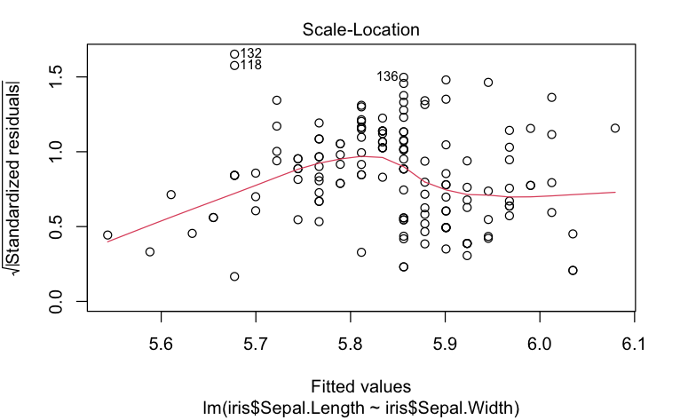

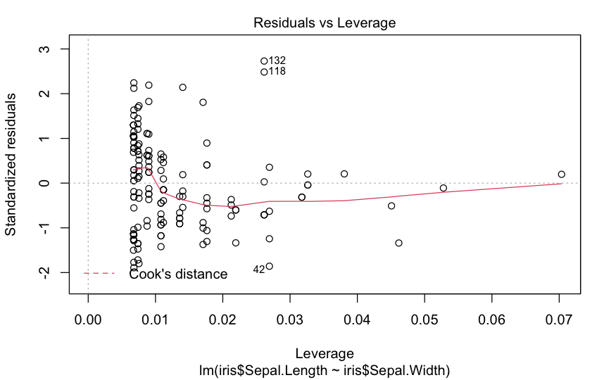

```r
plot( iris.reg )
```

# Logistic regression

## Model

```r
log_regr <- glm( mtcars$vs ~ ., data = mtcars, family = binomial( link = "logit" ) )
```

```
glm.fit: fitted probabilities numerically 0 or 1 occurred
```

```r
log_regr
```

```
Call:  glm(formula = mtcars$vs ~ ., family = binomial(link = "logit"),
    data = mtcars)

Coefficients:
(Intercept)          mpg          cyl         disp           hp         drat
  -389.3771       4.4343       5.6827      -0.5415       0.7611      -5.2957
         wt         qsec           am         gear        carb2        carb3
    13.2937      17.9896     -20.4263     -11.6572      -3.5644     -61.0122
      carb4        carb6        carb8
   -16.0235     -31.0984     -53.7962

Degrees of Freedom: 31 Total (i.e. Null);  17 Residual
Null Deviance:      43.86
Residual Deviance: 4.76e-10     AIC: 30
```

## Coefficients

```r
coef( log_regr )
```

```
 (Intercept)          mpg          cyl         disp           hp         drat
-389.3771088    4.4342544    5.6826543   -0.5415251    0.7611461   -5.2957263
          wt         qsec           am         gear        carb2        carb3
  13.2937265   17.9895928  -20.4262854  -11.6572415   -3.5644102  -61.0122225
       carb4        carb6        carb8
 -16.0234650  -31.0983991  -53.7961647
```

# Training and test sets

## Splitting

```r
library( caTools )

set.seed( 10 )
sample <- sample.split( mtcars$vs, SplitRatio = .75 )
sample
```

```
 [1]  TRUE  TRUE  TRUE FALSE  TRUE FALSE FALSE  TRUE FALSE  TRUE  TRUE  TRUE
[13]  TRUE  TRUE  TRUE FALSE  TRUE  TRUE FALSE  TRUE  TRUE FALSE  TRUE  TRUE
[25] FALSE  TRUE  TRUE  TRUE  TRUE  TRUE  TRUE  TRUE
```

```r
# select only the rows set as TRUE
train <- mtcars[ sample, ]
# or
train <- subset( mtcars, sample == TRUE )
train
```

|  | mpg | cyl | disp | hp | drat | wt | qsec | vs | am | gear | carb |
| --- | --- | --- | --- | --- | --- | --- | --- | --- | --- | --- | --- |
| Mazda RX4 | 21.0 | 6 | 160.0 | 110 | 3.90 | 2.620 | 16.46 | 0 | 1 | 4 | 4 |
| Mazda RX4 Wag | 21.0 | 6 | 160.0 | 110 | 3.90 | 2.875 | 17.02 | 0 | 1 | 4 | 4 |
| Datsun 710 | 22.8 | 4 | 108.0 | 93 | 3.85 | 2.320 | 18.61 | 1 | 1 | 4 | 1 |
| Hornet Sportabout | 18.7 | 8 | 360.0 | 175 | 3.15 | 3.440 | 17.02 | 0 | 0 | 3 | 2 |
| Merc 240D | 24.4 | 4 | 146.7 | 62 | 3.69 | 3.190 | 20.00 | 1 | 0 | 4 | 2 |
| Merc 280 | 19.2 | 6 | 167.6 | 123 | 3.92 | 3.440 | 18.30 | 1 | 0 | 4 | 4 |
| Merc 280C | 17.8 | 6 | 167.6 | 123 | 3.92 | 3.440 | 18.90 | 1 | 0 | 4 | 4 |
| Merc 450SE | 16.4 | 8 | 275.8 | 180 | 3.07 | 4.070 | 17.40 | 0 | 0 | 3 | 3 |
| Merc 450SL | 17.3 | 8 | 275.8 | 180 | 3.07 | 3.730 | 17.60 | 0 | 0 | 3 | 3 |
| Merc 450SLC | 15.2 | 8 | 275.8 | 180 | 3.07 | 3.780 | 18.00 | 0 | 0 | 3 | 3 |

[output cut: 14 more lines]

```r
# select only the rows set as FALSE
test <- mtcars[ !sample, ]
# or
test <- subset( mtcars, sample == FALSE )
test
```

|  | mpg | cyl | disp | hp | drat | wt | qsec | vs | am | gear | carb |
| --- | --- | --- | --- | --- | --- | --- | --- | --- | --- | --- | --- |
| Hornet 4 Drive | 21.4 | 6 | 258.0 | 110 | 3.08 | 3.215 | 19.44 | 1 | 0 | 3 | 1 |
| Valiant | 18.1 | 6 | 225.0 | 105 | 2.76 | 3.460 | 20.22 | 1 | 0 | 3 | 1 |
| Duster 360 | 14.3 | 8 | 360.0 | 245 | 3.21 | 3.570 | 15.84 | 0 | 0 | 3 | 4 |
| Merc 230 | 22.8 | 4 | 140.8 | 95 | 3.92 | 3.150 | 22.90 | 1 | 0 | 4 | 2 |
| Lincoln Continental | 10.4 | 8 | 460.0 | 215 | 3.00 | 5.424 | 17.82 | 0 | 0 | 3 | 4 |
| Honda Civic | 30.4 | 4 | 75.7 | 52 | 4.93 | 1.615 | 18.52 | 1 | 1 | 4 | 2 |
| Dodge Challenger | 15.5 | 8 | 318.0 | 150 | 2.76 | 3.520 | 16.87 | 0 | 0 | 3 | 2 |
| Pontiac Firebird | 19.2 | 8 | 400.0 | 175 | 3.08 | 3.845 | 17.05 | 0 | 0 | 3 | 2 |

## Training

> **Worth noting**: it may happen that in the test set, depending on the splitting, some categorical variables may present values which do not appear in the training set or viceversa. The seed in used to randomly split the dataset plays a crucial role in this behaviour.

```r
log_regr.split <- glm( train$vs ~ ., data = train, family = binomial( link = "logit" ) )
```

```
glm.fit: fitted probabilities numerically 0 or 1 occurred
```

```r
log_regr.split
```

```
Call:  glm(formula = train$vs ~ ., family = binomial(link = "logit"),
    data = train)

Coefficients:
(Intercept)          mpg          cyl         disp           hp         drat
  -171.9703      -1.6733      -3.6139      -0.4927       0.8114     -39.1153
         wt         qsec           am         gear        carb2        carb3
     3.8652      17.2005     -14.9594      20.8101     -20.3462     -74.7235
      carb4        carb6        carb8
   -25.3063     -94.3070    -138.6436

Degrees of Freedom: 23 Total (i.e. Null);  9 Residual
Null Deviance:      32.6
Residual Deviance: 5.72e-10     AIC: 30
```

## Prediction

```r
log_regr.predictions <- predict( log_regr.split, newdata = test, type = "response" )
log_regr.predictions
```

```
     Hornet 4 Drive             Valiant          Duster 360            Merc 230
       1.000000e+00        1.000000e+00        3.760101e-03        1.000000e+00
Lincoln Continental         Honda Civic    Dodge Challenger    Pontiac Firebird
       8.136625e-11        2.220446e-16        4.208851e-11        2.220446e-16
```

```r
threshold <- .5
log_regr.threshold <- ifelse( log_regr.predictions > threshold, 1, 0 )
log_regr.threshold
```

```
     Hornet 4 Drive             Valiant          Duster 360            Merc 230
                  1                   1                   0                   1
Lincoln Continental         Honda Civic    Dodge Challenger    Pontiac Firebird
                  0                   0                   0                   0
```

## Confusion matrix and performance measures

```r
library( caret )
confusionMatrix( as.factor( log_regr.threshold ), reference = as.factor( test$vs ) )
```

```
Confusion Matrix and Statistics

          Reference
Prediction 0 1
         0 4 1
         1 0 3

               Accuracy : 0.875
                 95% CI : (0.4735, 0.9968)
    No Information Rate : 0.5
    P-Value [Acc > NIR] : 0.03516

                  Kappa : 0.75

 Mcnemar's Test P-Value : 1.00000

            Sensitivity : 1.000
            Specificity : 0.750
         Pos Pred Value : 0.800
         Neg Pred Value : 1.000
             Prevalence : 0.500
         Detection Rate : 0.500
   Detection Prevalence : 0.625
      Balanced Accuracy : 0.875

       'Positive' Class : 0
```

```r
library( ROCR )
library( Metrics )

predictions <- prediction( log_regr.predictions, test$vs )
predictions
```

```
A prediction instance
  with 8 data points
```

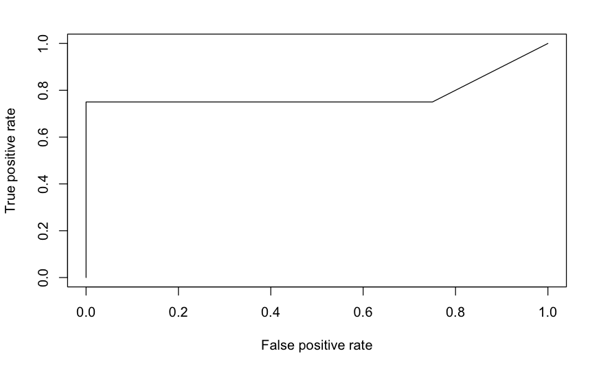

```r
perf <- performance( predictions, measure = "tpr", x.measure = "fpr" )
plot( perf )
```

```r
auc( test$vs, log_regr.threshold )
```

```
[1] 0.875
```

# Classification trees

```r
library( ISLR )
head( Carseats )
```

|  | Sales | CompPrice | Income | Advertising | Population | Price | ShelveLoc | Age | Education | Urban | US |
| --- | --- | --- | --- | --- | --- | --- | --- | --- | --- | --- | --- |
| 1 | 9.50 | 138 | 73 | 11 | 276 | 120 | Bad | 42 | 17 | Yes | Yes |
| 2 | 11.22 | 111 | 48 | 16 | 260 | 83 | Good | 65 | 10 | Yes | Yes |
| 3 | 10.06 | 113 | 35 | 10 | 269 | 80 | Medium | 59 | 12 | Yes | Yes |
| 4 | 7.40 | 117 | 100 | 4 | 466 | 97 | Medium | 55 | 14 | Yes | Yes |
| 5 | 4.15 | 141 | 64 | 3 | 340 | 128 | Bad | 38 | 13 | Yes | No |
| 6 | 10.81 | 124 | 113 | 13 | 501 | 72 | Bad | 78 | 16 | No | Yes |

## Dataset preparation

Assume we want to predict the variable `sales` and that we want to create a categorical variable out of this, which describes whether the sale is high or not. In our example “high” means greater than 8.

```r
High <- as.factor( ifelse( Carseats$Sales <= 8, "No", "Yes" ) )
High
```

```
  [1] Yes Yes Yes No  No  Yes No  Yes No  No  Yes Yes No  Yes Yes Yes No  Yes Yes
 [20] Yes No  Yes No  No  Yes Yes Yes No  No  No  Yes Yes No  Yes No  Yes Yes No
 [39] No  No  No  No  Yes No  No  No  Yes No  No  Yes No  No  No  No  No  No  Yes
 [58] No  No  No  Yes No  No  Yes No  No  Yes Yes Yes No  Yes No  No  Yes No  Yes
 [77] Yes No  No  Yes Yes No  Yes No  No  Yes Yes Yes No  No  No  No  No  Yes Yes
 [96] No  Yes No  Yes No  No  No  No  No  No  No  No  Yes No  Yes Yes No  No  No
[115] Yes Yes No  Yes No  No  No  Yes No  Yes Yes Yes Yes No  No  No  Yes No  Yes
[134] No  No  No  No  No  Yes Yes No  No  No  No  Yes Yes No  Yes No  Yes Yes Yes
[153] No  No  No  No  No  Yes Yes Yes No  No  No  No  Yes No  No  No  No  Yes Yes
[172] Yes Yes No  No  No  No  Yes Yes No  No  No  No  No  Yes Yes Yes No  Yes Yes
[191] Yes No  No  Yes No  No  No  No  No  No  No  No  No  No  Yes No  No  Yes No
[210] No  No  Yes Yes Yes No  No  No  No  Yes Yes Yes No  No  No  No  No  No  Yes
[229] No  Yes No  Yes Yes Yes Yes No  Yes Yes No  No  Yes Yes No  No  Yes Yes No
[248] No  No  No  Yes No  Yes No  Yes No  No  Yes No  No  No  No  No  No  No  No
[267] Yes No  No  No  Yes No  Yes Yes No  No  No  No  No  No  No  Yes No  No  No
[286] No  No  No  No  Yes Yes No  Yes Yes Yes No  Yes No  Yes Yes Yes No  No  Yes
[305] Yes Yes No  No  Yes Yes Yes No  No  Yes No  No  Yes No  Yes No  No  No  Yes
[324] Yes No  Yes No  No  No  Yes No  Yes No  No  No  No  No  Yes No  Yes No  No
[343] No  No  Yes No  Yes No  Yes Yes Yes Yes Yes Yes No  No  No  Yes No  No  Yes
[362] Yes No  Yes Yes No  No  Yes Yes Yes No  Yes No  No  Yes No  Yes No  No  No
[381] Yes No  No  Yes Yes No  No  Yes Yes Yes No  No  No  No  No  Yes No  No  No
[400] Yes
Levels: No Yes
```

```r
# Add the column to the dataset
carseats <- data.frame( Carseats, High )
head( carseats )
```

|  | Sales | CompPrice | Income | Advertising | Population | Price | ShelveLoc | Age | Education | Urban | US | High |
| --- | --- | --- | --- | --- | --- | --- | --- | --- | --- | --- | --- | --- |
| 1 | 9.50 | 138 | 73 | 11 | 276 | 120 | Bad | 42 | 17 | Yes | Yes | Yes |
| 2 | 11.22 | 111 | 48 | 16 | 260 | 83 | Good | 65 | 10 | Yes | Yes | Yes |
| 3 | 10.06 | 113 | 35 | 10 | 269 | 80 | Medium | 59 | 12 | Yes | Yes | Yes |
| 4 | 7.40 | 117 | 100 | 4 | 466 | 97 | Medium | 55 | 14 | Yes | Yes | No |
| 5 | 4.15 | 141 | 64 | 3 | 340 | 128 | Bad | 38 | 13 | Yes | No | No |
| 6 | 10.81 | 124 | 113 | 13 | 501 | 72 | Bad | 78 | 16 | No | Yes | Yes |

> **Be careful**: the newly created categorical (binary) variable must be saved as a factor to be correctly processed by the classification tree. If it is saved as character it will not be processed in the correct way. Let’s suppose we want to build a classification tree to predict the variable `High` exploiting all the other variables except for the `Sales` one - which already contains correlated information.

## Training and plotting

```r
library( tree )

# remove sales from carseats
carseats <- carseats[ -c( 1 ) ]

tree.carseats <- tree( High~., data = carseats )
summary( tree.carseats )
```

```
Classification tree:
tree(formula = High ~ ., data = carseats)
Variables actually used in tree construction:
[1] "ShelveLoc"   "Price"       "Income"      "CompPrice"   "Population"
[6] "Advertising" "Age"         "US"
Number of terminal nodes:  27
Residual mean deviance:  0.4575 = 170.7 / 373
Misclassification error rate: 0.09 = 36 / 400
```

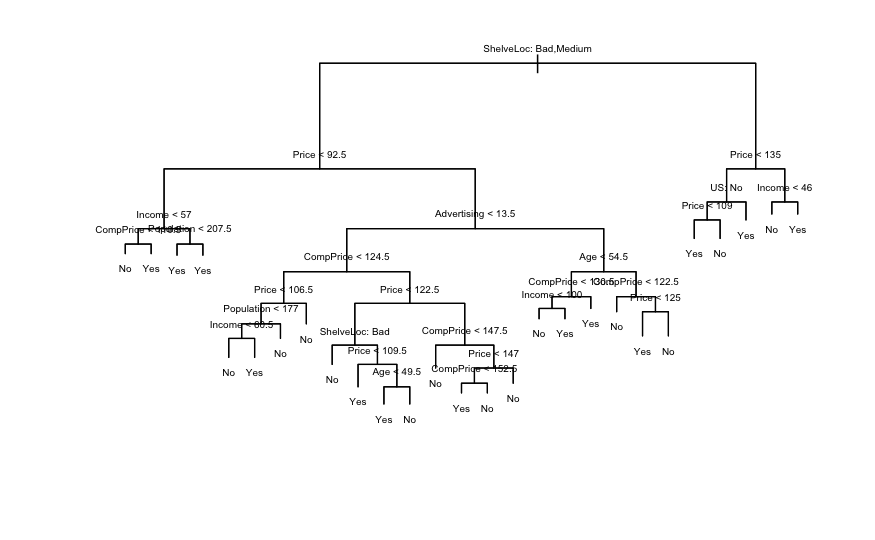

```r
plot( tree.carseats )
text( tree.carseats, pretty = 0, cex = .5 )
```

## Pruning

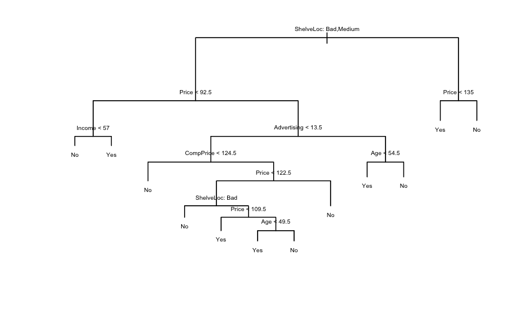

```r
prune.carseats <- prune.misclass( tree.carseats, best = 12 )
plot( prune.carseats )
text( prune.carseats, pretty = 0, cex = .5 )
```

## Complete model construction and comparisons of performances

```r
# get the idx of the training samples
train_idx <- sample( 1:nrow( carseats ), 250 )
# build the tree on the training samples
tree.carseats_train <- tree( High~., data = carseats, subset = train_idx )
# predict on the test set
tree.predictions_whole <- predict( tree.carseats_train, carseats[ -train_idx, ], type = 'class' )
tree.predictions_whole
```

```
  [1] No  Yes No  No  No  No  No  No  No  Yes Yes Yes No  No  No  Yes No  Yes No
 [20] No  No  No  Yes No  Yes No  No  No  No  No  Yes Yes No  No  Yes Yes No  Yes
 [39] No  No  No  No  Yes Yes Yes No  Yes Yes Yes No  No  Yes No  No  Yes Yes Yes
 [58] Yes Yes Yes No  No  No  No  No  No  No  No  Yes No  Yes No  Yes No  Yes Yes
 [77] No  No  No  No  No  No  No  No  No  No  No  Yes No  No  No  No  No  Yes No
 [96] No  Yes No  No  No  No  No  No  No  No  Yes No  Yes Yes Yes Yes No  No  Yes
[115] Yes Yes Yes No  No  No  Yes Yes Yes No  No  No  Yes No  Yes Yes No  Yes Yes
[134] Yes No  Yes Yes Yes No  Yes No  No  No  Yes No  No  No  No  No  No
Levels: No Yes
```

```r
# misclassification table
with( carseats[ -train_idx, ], table( tree.predictions_whole, High ) )
```

```
                      High
tree.predictions_whole No Yes
                   No  66  27
                   Yes 25  32
```

```r
# prune tree
prune.carseats_train <- prune.misclass( tree.carseats_train, best = 12 )
# predict on the test set
tree.predictions_prune <- predict( prune.carseats_train, carseats[ -train_idx, ], type = 'class' )
tree.predictions_prune
```

```
  [1] No  Yes No  No  No  No  No  No  No  Yes Yes Yes No  No  No  Yes No  Yes No
 [20] No  No  No  Yes No  Yes No  No  Yes No  No  Yes Yes No  No  Yes Yes No  Yes
 [39] No  No  No  No  Yes Yes Yes No  Yes Yes Yes No  No  Yes No  No  Yes Yes Yes
 [58] Yes Yes Yes No  No  No  No  No  No  No  No  Yes No  Yes No  Yes Yes Yes Yes
 [77] No  No  No  No  No  No  No  No  No  No  No  Yes No  No  No  No  No  Yes No
 [96] No  Yes No  No  No  No  No  No  No  No  Yes No  Yes Yes Yes Yes Yes No  Yes
[115] Yes Yes Yes No  No  No  Yes Yes Yes No  No  No  Yes No  Yes Yes No  Yes Yes
[134] Yes No  Yes Yes Yes No  Yes No  No  No  Yes No  No  No  No  No  No
Levels: No Yes
```

```r
# misclassification table
with( carseats[ -train_idx, ], table( tree.predictions_prune, High ) )
```

```
                      High
tree.predictions_prune No Yes
                   No  64  26
                   Yes 27  33
```

## Random Forests

```r
library( MASS )
library( randomForest )

# import dataset
boston <- Boston
dim( boston )
```

```
[1] 506  14
```

```r
names( boston )
```

```
 [1] "crim"    "zn"      "indus"   "chas"    "nox"     "rm"      "age"     "dis"     "rad"
[10] "tax"     "ptratio" "black"   "lstat"   "medv"
```

```r
# creating training and testing
set.seed( 101 )
train <- sample( 1:nrow( boston ), 300 )

# model
rf.boston <- randomForest( medv~., data = boston, subset = train )
rf.boston
```

```
Call:
 randomForest(formula = medv ~ ., data = boston, subset = train)
               Type of random forest: regression
                     Number of trees: 500
No. of variables tried at each split: 4

          Mean of squared residuals: 12.68651
                    % Var explained: 83.45
```

# Bayesian methods

## Näive Bayes classifier

```r
library( e1071 )
library( MASS )
# dataset
titanic <- as.data.frame( Titanic )
titanic
```

| Class | Sex | Age | Survived | Freq |
| --- | --- | --- | --- | --- |
| 1st | Male | Child | No | 0 |
| 2nd | Male | Child | No | 0 |
| 3rd | Male | Child | No | 35 |
| Crew | Male | Child | No | 0 |
| 1st | Female | Child | No | 0 |
| 2nd | Female | Child | No | 0 |
| 3rd | Female | Child | No | 17 |
| Crew | Female | Child | No | 0 |
| 1st | Male | Adult | No | 118 |
| 2nd | Male | Adult | No | 154 |

[output cut: 22 more lines]

```r
# split in training and test set
samples <- sample( 1:nrow( titanic ), 20 )
titanic.train <- titanic[ samples, ]
titanic.test <- titanic[ -samples, ]

# predict survived variable via Näive Bayes
titanic.nb <- naiveBayes( Survived~., data = titanic.train )
titanic.predicted <- predict( titanic.nb, newdata = titanic.test )
table(titanic.predicted, titanic.test$Survived )
```

```
titanic.predicted No Yes
              No   1   0
              Yes  7   4
```

## Bayesian Networks

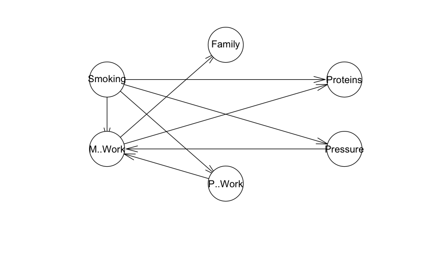

```r
library( bnlearn )

# import dataset
cor_df <- data.frame( coronary )
# hc function: fits a bayesian network to the dataset
res <- hc( cor_df )
plot( res )
```

```r
res$arcs
```

```
     from       to
[1,] "M..Work"  "Proteins"
[2,] "Smoking"  "M..Work"
[3,] "Smoking"  "Proteins"
[4,] "Smoking"  "P..Work"
[5,] "Pressure" "M..Work"
[6,] "P..Work"  "M..Work"
[7,] "M..Work"  "Family"
[8,] "Smoking"  "Pressure"
```

If one wants to remove some connections between variables, it is possible by modifying the `arcs` feature.

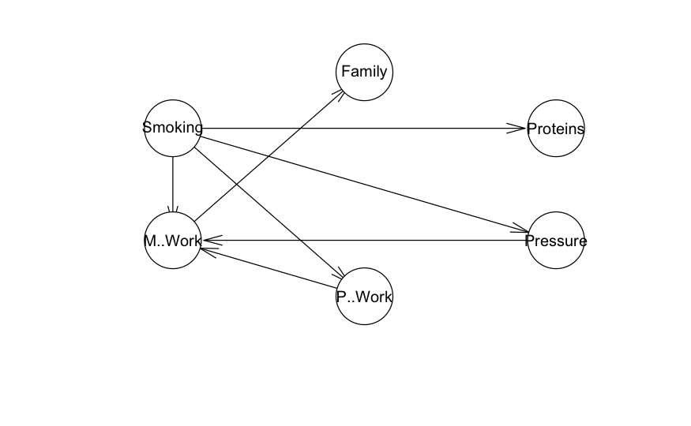

```r
remove_idx <- which( res$arcs[ , 'from' ] == "M..Work" & res$arcs[ , 'to' ] == "Proteins" )
res$arcs <- res$arcs[ -remove_idx, ]
plot( res )
```

After learning the structure, we need to find out the conditional probability tables (CPTs) at each node. The `bn.fit` function fits, assigns or replaces the parameters of a Bayesian network conditional on its structure.

```r
fitted_bn <- bn.fit( res, data = cor_df )
print( fitted_bn$Proteins )
```

```
  Parameters of node Proteins (multinomial distribution)

Conditional probability table:

, , M..Work = no

        Smoking
Proteins        no       yes
      <3 0.6685824 0.6167763
      >3 0.3314176 0.3832237

, , M..Work = yes

        Smoking
Proteins        no       yes
      <3 0.5671982 0.3235294
      >3 0.4328018 0.6764706
```

What is the chance of having a protein less than 3, given that smoke is equal to “no”?

```r
cpquery( fitted_bn, event = ( Proteins == "<3" ), evidence = ( Smoking == "no" ) )
```

```
[1] 0.6392816
```